# Finding Similar Board Games

Phil Henrickson

2021-12-12

## What is this analysis?

This notebook is for selecting any boardgame and identifying **its most comparable games using data from boardgamegeek.com**. I use a dimension reduction method (PCA) to learn the main points of variation in data about games from boardgamegee - this gives me a vector with every game’s value on each of the principal components. To find similar games, I compute the distance between all games using the first ten principal components. I use the distance between games to determine their overall similarity. Games that are close to each other are said to be *neighbors*.

This document details a game’s 25 nearest neighbors and illustrate some of the dimensions that make the selected game and its neighbors similar.

## Game Profile: **Parsifal: A Game of Tarots**

Summary information for the selected game.

| ID | Game | Published | Player Count | Playing Time | UserRatings | Average | GeekRating | Complexity |
| --- | --- | --- | --- | --- | --- | --- | --- | --- |
| 350890 | Parsifal: A Game of Tarots | 2021 | 2-6 | 90 min | 5 | 7 |  |  |

Information on the game’s designers, artists, mechanics and categories. Note: designer and artist features are not used in identifying nearest neighbors.

| Designer(s) | Artist(s) | Categories | Mechanics |
| --- | --- | --- | --- |
| Osvaldo Duilio Rossi | Emanuele Ercolani | Card Game | Variable Player Powers |
|  |  | Fantasy | Storytelling |
|  |  | Medieval | Hand Management |
|  |  | Music | Player Elimination |
|  |  |  | Semicooperative Game |
|  |  |  | Scenario Mission Campaign Game |
|  |  |  | Lose A Turn |
|  |  |  | Interrupts |
|  |  |  | Command Cards |
|  |  |  | Alliances |
|  |  |  | Chaining |
|  |  |  | Induction |
|  |  |  | Matching |

For the full profile of the selected game, go to https://boardgamegeek.com/boardgame/350890

## Most Similar Games to **Parsifal: A Game of Tarots**

The table below displays the most similar games to Parsifal: A Game of Tarots using data from boardgamegeek (BGG). The reported similarity score is the (squared) inverse of the Manhattan distance between two games.

**Note:** The analysis does not make use of a game’s number of ratings, average, or geek average, but instead looks only at a game’s categories, mechanics, playing time, player count, and complexity. The current approach for computing the distance weighs each component equally; I plan to explore a change to this in the future by using different measures of distance, as we would reasonably expect some components to be more important than others. I initially relied on Euclidean distance, but in tinkering with the results I have opted to go with the Manhattan distance for now.

| Rank | Similarity | Published | ID | Neighbor | BGGRating | GeekRating | Complexity |
| --- | --- | --- | --- | --- | --- | --- | --- |
| 1 | 37.10 | 2013 | 123123 | BattleCON: Devastation of Indines | 7.90 | 6.99 | 3.09 |
| 2 | 36.47 | 2015 | 173018 | Grimslingers | 6.28 | 5.72 | 2.74 |
| 3 | 35.95 | 2012 | 118063 | Android: Infiltration | 6.53 | 6.19 | 2.10 |
| 4 | 35.69 | 2015 | 162591 | Heroes | 6.09 | 5.61 | 2.31 |
| 5 | 35.55 | 2010 | 71721 | Space Hulk: Death Angel – The Card Game | 7.00 | 6.77 | 2.42 |
| 6 | 35.46 | 2021 | 308621 | Twisted Fables | 8.31 | 5.68 | 2.90 |
| 7 | 35.24 | 2021 | 336382 | Marvel United: X-Men | 8.32 | 5.88 | 2.33 |
| 8 | 35.23 | 2021 | 328871 | Terraforming Mars: Ares Expedition | 7.67 | 6.92 | 2.91 |
| 9 | 34.89 | 2018 | 192296 | The Pirate Republic | 7.37 | 5.65 | 2.93 |
| 10 | 34.55 | 2015 | 171233 | The Big Book of Madness | 6.95 | 6.60 | 2.69 |
| 11 | 34.52 | 2021 | 283387 | Rocketmen | 6.99 | 6.02 | 2.62 |
| 12 | 34.39 | 2016 | 176083 | Hit Z Road | 6.77 | 6.34 | 1.86 |
| 13 | 34.35 | 2019 | 272409 | Tiny Epic Tactics | 6.90 | 6.00 | 2.48 |
| 14 | 34.28 | 2016 | 195856 | Bloodborne: The Card Game | 6.90 | 6.33 | 2.08 |
| 15 | 34.16 | 2021 | 302413 | Steamwatchers | 7.96 | 5.64 | 3.30 |
| 16 | 34.16 | 2013 | 147474 | 8 Masters' Revenge | 6.32 | 5.59 | 2.46 |
| 17 | 34.15 | 2019 | 284083 | The Crew: The Quest for Planet Nine | 7.97 | 7.77 | 1.99 |
| 18 | 34.14 | 2016 | 193840 | The Dragon & Flagon | 6.43 | 5.88 | 2.37 |
| 19 | 34.10 | 2003 | 9108 | Masquerade | 6.03 | 5.59 | 2.29 |
| 20 | 34.03 | 2018 | 230253 | Star Realms: Frontiers | 8.00 | 7.09 | 1.88 |
| 21 | 33.88 | 2015 | 169544 | Bright Future | 6.67 | 5.59 | 2.83 |
| 22 | 33.86 | 2014 | 154301 | The Battle at Kemble's Cascade | 6.71 | 6.04 | 2.57 |
| 23 | 33.81 | 2010 | 79073 | Resident Evil Deck Building Game | 6.57 | 5.96 | 2.28 |
| 24 | 33.80 | 2020 | 314040 | Pandemic Legacy: Season 0 | 8.65 | 7.53 | 3.03 |
| 25 | 33.78 | 2016 | 189932 | Tyrants of the Underdark | 7.91 | 7.31 | 2.57 |

## Plotting Comparable Games to **Parsifal: A Game of Tarots**

Placing the selected game and its nearest neighbors on the first two principal components.

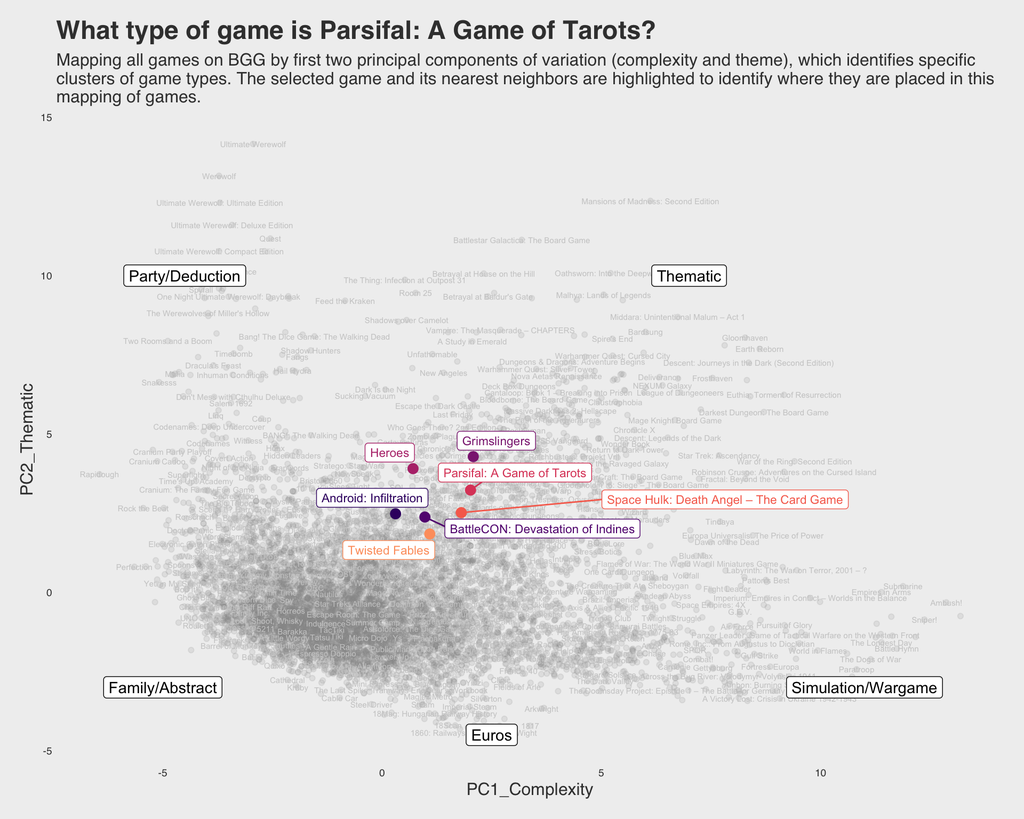

Placing games on the first four principal components, which I have found to loosely map to complexity, theme, economy, and cooperation.

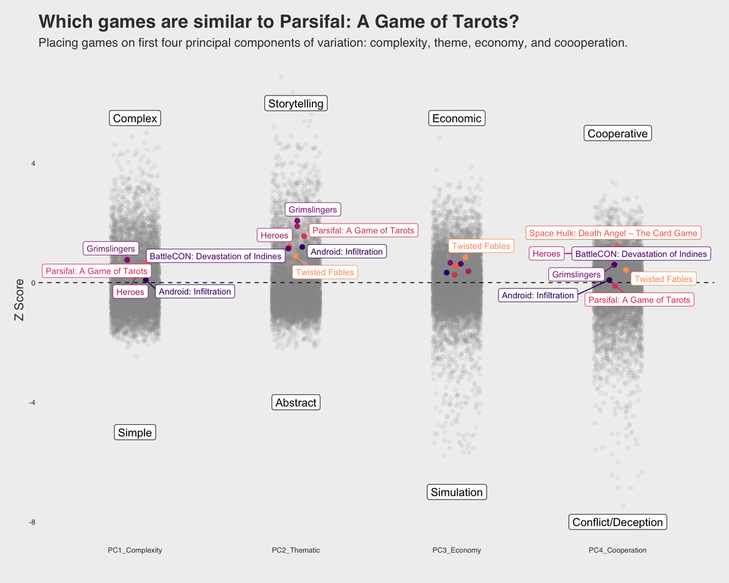